# A Bayesian Time-Varying Load Apportionment Model for Daily Prediction and Source Apportionment of Orthophosphate

Thames, Trent, and Severn

Fenanda Dwitha Kurniasari (S2744048)

2026-06-25

# 1 Packages

```r
library(brms)
library(tidyverse)
library(posterior)
library(bayesplot)
library(tidybayes)
library(lubridate)
library(patchwork)
library(moments)
library(dplyr)
```

# 2 Data Preparation

## 2.1 Data Collection

Already stored in `R.data` file. If you want to run again from the start, remove comment below `"`

```r
# source("import_wq_function.R")
# source("import_hde_function.R")
#
# conc_sites <- c("TH-PTHR0107", # Thames at Teddington
#                 "MD-00025085",# Severn at Haw Bridge
#                 "NE-45400013",# Tees at Low Worsall
#                 "NW-88006427",# Eden at Sheepmount
#                 "MD-36701570",# Trent at Dunham
#                 "AN-WEN250",# Wensum at Sweet Briar
#                 "NW-88003872" # Wyre nr St Michaels
#                 )
#
# flow_sites <- c("3400TH", "2606", "F3606", "765512",
#                 "4022", "034001", "720517")
#
#
# # Import concentration data — all determinands so we can check censoring first
# det_codes <- c("0180",# Orthophosphate
#                "0117",# Nitrate
#                "0111",# Ammonia
#                "3408")# Dissolved Zinc
#
# conc_df <- NULL
# for (i in seq_along(conc_sites)) {
#   tmp <- import_wq(
#     sites = conc_sites[i],
#     dets = det_codes,
#     start_date = "2000-01-01",
#     end_date = "2025-12-31",
#     save = FALSE
#   )
#   conc_df <- rbind(conc_df, tmp)
# }
#
# # Import flow data
# flow_df <- NULL
# for (i in seq_along(flow_sites)) {
#   tmp <- import_hde(
#     sites = flow_sites[i],
#     start_date = "2000-01-01",
#     end_date = "2025-12-31"
#   )
#   flow_df <- rbind(flow_df, tmp)
# }

# Open datasets
load("dataset per 31 december 2025 (used).RData")
```

## 2.2 Clean Concentration Data

Orthophosphate observations with qualifier `"<"` are left-censored (below the limit of detection, LOD). Where multiple measurements fall on the same day: if all are censored, we keep the minimum LOD. If any are detected, we average the detected values only.

```r
op_det <- c("Orthophosphate, reactive as P")

conc_op <- conc_df %>%
  filter(determinand %in% op_det) %>%
  mutate(
    date     = as.Date(date_time),
    censored = !is.na(qualifier) & qualifier == "<"
  ) %>%
  group_by(wq_site_name, date) %>%
  summarise(
    # All censored,keep minimum LOD (Limit of Detection)
    # Any detected, mean of detected values only (to make sure one daily concentration data)
    result   = ifelse(all(censored, na.rm = TRUE),
                      min(result),
                      mean(result[!censored], na.rm = TRUE)),
    censored = all(censored, na.rm = TRUE)
  ) %>%
  ungroup()

summary(conc_op)
```

```
##  wq_site_name            date                result         censored
##  Length:5182        Min.   :2000-01-06   Min.   :0.00100   Mode :logical
##  Class :character   1st Qu.:2009-04-02   1st Qu.:0.04700   FALSE:4929
##  Mode  :character   Median :2013-06-07   Median :0.08625   TRUE :253
##                     Mean   :2013-11-03   Mean   :0.15745
##                     3rd Qu.:2018-06-11   3rd Qu.:0.16900
##                     Max.   :2025-12-23   Max.   :2.38500
```

## 2.3 Clean Flow Data

Recode each NRFA gauge ID to the corresponding EA water quality site

```r
flow_clean <- flow_df %>%
  mutate(
    wq_site_name = case_when(
      flow_site_id == "3400TH"  ~ "THAMES AT TEDDINGTON WEIR",
      flow_site_id == "2606" ~ "RIVER SEVERN (LOWER) HAW BRIDGE",
      flow_site_id == "F3606" ~ "TEES AT LOW WORSALL",
      flow_site_id == "765512" ~ "RIVER EDEN AT SHEEPMOUNT",
      flow_site_id == "4022" ~ "TIDAL TRENT - RIVER TRENT AT DUNHAM",
      flow_site_id == "034001" ~ "R.WENSUM SWEET BRIAR RD.BR.",
      flow_site_id == "720517" ~ "RIVER WYRE AT ST MICHAELS"
    )
  ) %>%
  filter(!is.na(wq_site_name), !is.na(flow)) %>%
  group_by(wq_site_name, date) %>%
  summarise(flow = mean(flow, na.rm = TRUE)) %>% ungroup()

summary(flow_clean)
```

```
##  wq_site_name            date                 flow
##  Length:64957       Min.   :2000-01-01   Min.   :   0.141
##  Class :character   1st Qu.:2006-05-13   1st Qu.:   4.890
##  Mode  :character   Median :2012-10-22   Median :  23.931
##                     Mean   :2012-12-14   Mean   :  50.076
##                     3rd Qu.:2019-07-20   3rd Qu.:  60.725
##                     Max.   :2025-12-31   Max.   :1166.946
```

## 2.4 Join, Transform, and Create Time Index

Concentration and flow are matched by site and date. Both are log₁₀-transformed before modelling. A continuous time index (years since first observation at each site) is created for the time-varying splines in M2 and M3.

```r
df_used <- conc_op %>%
  left_join(flow_clean, by = c("wq_site_name", "date")) %>%
  filter(!is.na(flow), !is.na(result), result > 0) %>%
  mutate(
    site_short = case_when(
      wq_site_name == "THAMES AT TEDDINGTON WEIR" ~ "Thames",
      wq_site_name == "TIDAL TRENT - RIVER TRENT AT DUNHAM" ~ "Trent",
      wq_site_name == "RIVER SEVERN (LOWER) HAW BRIDGE" ~ "Severn",
      wq_site_name == "TEES AT LOW WORSALL" ~ "Tees",
      wq_site_name == "RIVER EDEN AT SHEEPMOUNT"~ "Eden",
      wq_site_name == "R.WENSUM SWEET BRIAR RD.BR." ~ "Wensum",
      wq_site_name == "RIVER WYRE AT ST MICHAELS" ~ "Wyre"
    ),
    site_short = factor(site_short,
                        levels = c("Thames", "Trent", "Severn",
                                   "Tees", "Eden", "Wensum", "Wyre")),
    year  = year(date),
    month  = month(date),
    log10_conc = log10(result),
    log10_flow = log10(flow),
    cens_flag = if_else(censored, "left", "none"),
    detected = !censored
  ) %>%
  group_by(site_short) %>%
  # time_index, years elapsed since first observation at each site
  mutate(time_index = as.numeric(date - min(date)) / 365.25) %>%
  ungroup()

summary(df_used)
```

```
##  wq_site_name            date                result        censored
##  Length:5127        Min.   :2000-01-06   Min.   :0.0010   Mode :logical
##  Class :character   1st Qu.:2009-03-24   1st Qu.:0.0470   FALSE:4874
##  Mode  :character   Median :2013-05-20   Median :0.0850   TRUE :253
##                     Mean   :2013-10-30   Mean   :0.1571
##                     3rd Qu.:2018-06-20   3rd Qu.:0.1680
##                     Max.   :2025-12-23   Max.   :2.3850
##
##       flow          site_short        year          month
##  Min.   :  0.157   Thames: 361   Min.   :2000   Min.   : 1.000
##  1st Qu.:  1.580   Trent : 299   1st Qu.:2009   1st Qu.: 3.000
##  Median : 10.655   Severn: 261   Median :2013   Median : 7.000
##  Mean   : 36.919   Tees  : 261   Mean   :2013   Mean   : 6.579
##  3rd Qu.: 41.304   Eden  :1122   3rd Qu.:2018   3rd Qu.:10.000
##  Max.   :769.891   Wensum:1569   Max.   :2025   Max.   :12.000
##                    Wyre  :1254
##    log10_conc        log10_flow       cens_flag          detected
##  Min.   :-3.0000   Min.   :-0.8041   Length:5127        Mode :logical
##  1st Qu.:-1.3279   1st Qu.: 0.1987   Class :character   FALSE:253
##  Median :-1.0706   Median : 1.0276   Mode  :character   TRUE :4874
##  Mean   :-1.0432   Mean   : 0.9358
##  3rd Qu.:-0.7747   3rd Qu.: 1.6160
##  Max.   : 0.3775   Max.   : 2.8864
##
##    time_index
##  Min.   : 0.000
##  1st Qu.: 9.053
##  Median :13.218
##  Mean   :13.679
##  3rd Qu.:18.287
##  Max.   :25.930
##
```

## 2.5 Exploratory Data per Sites

We screen all seven candidate sites against, with some criteria, which are n ≥100 observations, ≤40% censoring, ≥10 years of record, and median concentration >0.01 mg/L.

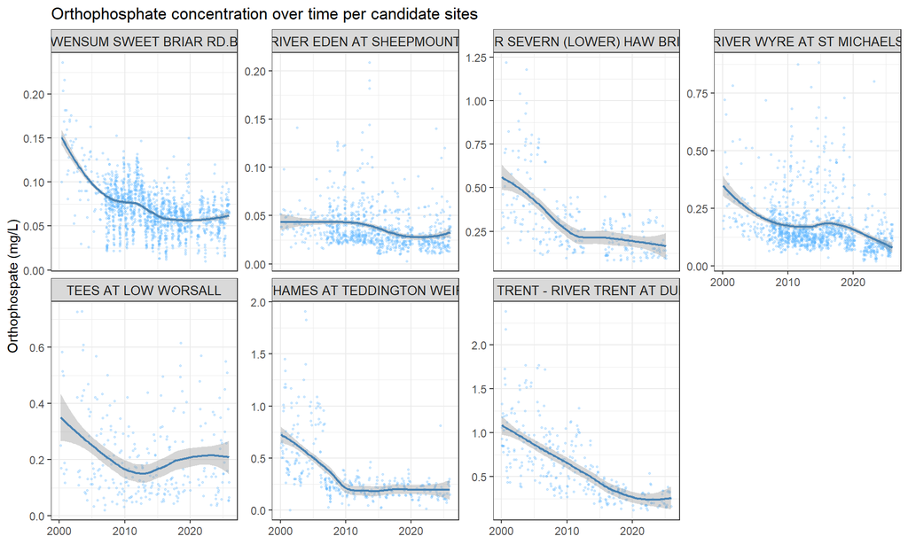

```r
site_summary <- df_used %>%
  group_by(wq_site_name) %>%
  summarise(
    n = n(),
    n_cens = sum(censored),
    pct_cens = round(100 * mean(censored), 1),
    year_min  = min(year(date)),
    year_max = max(year(date)),
    n_years = year_max - year_min + 1,
    conc_median = round(median(result[!censored]), 4),
    conc_min = round(min(result), 4),
    conc_max = round(max(result), 4),
    flow_median = round(median(flow), 2)
  ) %>%
  ungroup() %>%
  mutate(
    flag_n = n >= 100,
    flag_cens  = pct_cens <= 40,
    flag_years = n_years >= 10,
    flag_conc  = conc_median > 0.01,
    score = flag_n + flag_cens + flag_years + flag_conc,
    recommended = score == 4
  )


#Concentration Trend over time
ggplot(df_used %>% filter(detected),
       aes(x = date, y = result)) +
  geom_point(alpha = 0.3, size = 0.6, colour = "steelblue1") +
  geom_smooth(method = "loess", se = TRUE,
              colour = "steelblue", linewidth = 0.8) +
  facet_wrap(~wq_site_name, scales = "free_y", ncol = 4) +
  labs(title    = "Orthophosphate concentration over time per candidate sites",
       x = NULL, y = "Orthophospate (mg/L)") +
  theme_bw() +
  theme(strip.text = element_text(size = 10))
```

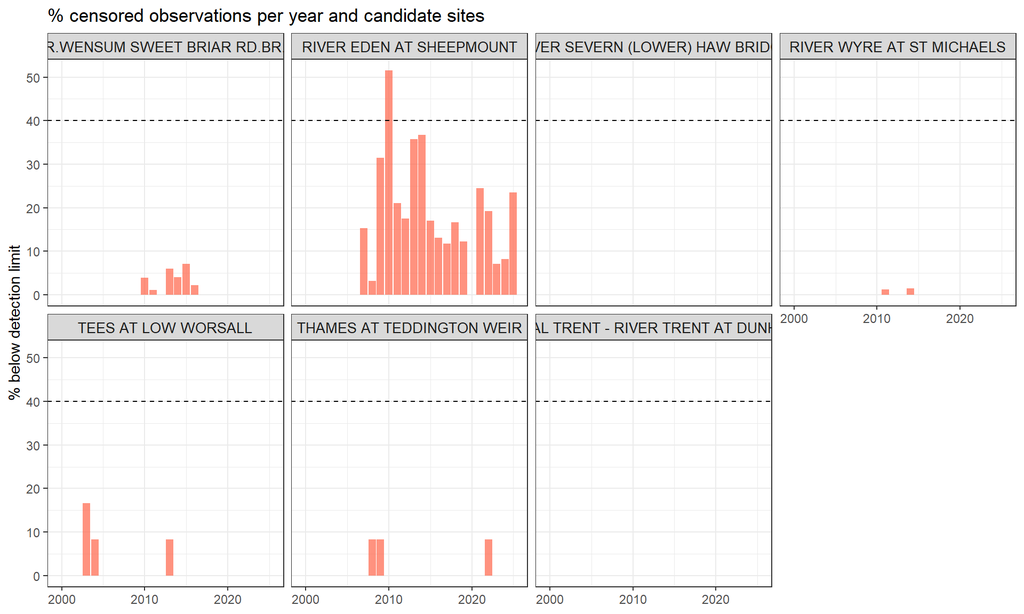

```r
ggsave("output_img/vers15_op_site_selection_trend.png", width = 14, height = 6, dpi = 150)

#Censoring Profile
ggplot(df_used %>%
         group_by(wq_site_name, year = year(date)) %>%
         summarise(pct_cens = 100 * mean(!detected)) %>% ungroup(),
       aes(x = year, y = pct_cens)) +
  geom_col(fill = "tomato", alpha = 0.7) +
  geom_hline(yintercept = 40, linetype = "dashed",
             colour = "black", linewidth = 0.5) +
  facet_wrap(~wq_site_name, ncol = 4) +
  labs(title    = "% censored observations per year and candidate sites",
       x = NULL, y = "% below detection limit") +
  theme_bw() +
  theme(strip.text = element_text(size = 10))
```

```r
ggsave("output_img/vers15_op_site_selection_censoring.png", width = 14, height = 6, dpi = 150)

site_summary
```

| wq_site_name | n | n_cens | pct_cens | year_min | year_max | n_years | conc_median | conc_min | conc_max | flow_median | flag_n | flag_cens | flag_years | flag_conc | score | recommended |
| --- | --- | --- | --- | --- | --- | --- | --- | --- | --- | --- | --- | --- | --- | --- | --- | --- |
| R.WENSUM SWEET BRIAR RD.BR. | 1569 | 24 | 1.5 | 2000 | 2025 | 26 | 0.0670 | 0.0100 | 0.2360 | 0.97 | TRUE | TRUE | TRUE | TRUE | 4 | TRUE |
| RIVER EDEN AT SHEEPMOUNT | 1122 | 220 | 19.6 | 2000 | 2025 | 26 | 0.0300 | 0.0028 | 0.2087 | 47.21 | TRUE | TRUE | TRUE | TRUE | 4 | TRUE |
| RIVER SEVERN (LOWER) HAW BRIDGE | 261 | 0 | 0.0 | 2000 | 2025 | 26 | 0.2590 | 0.0780 | 1.2200 | 58.43 | TRUE | TRUE | TRUE | TRUE | 4 | TRUE |
| RIVER WYRE AT ST MICHAELS | 1254 | 2 | 0.2 | 2000 | 2025 | 26 | 0.1390 | 0.0200 | 0.8820 | 5.11 | TRUE | TRUE | TRUE | TRUE | 4 | TRUE |
| TEES AT LOW WORSALL | 261 | 4 | 1.5 | 2000 | 2025 | 26 | 0.1500 | 0.0200 | 2.0000 | 13.28 | TRUE | TRUE | TRUE | TRUE | 4 | TRUE |
| THAMES AT TEDDINGTON WEIR | 361 | 3 | 0.8 | 2000 | 2025 | 26 | 0.2515 | 0.0010 | 1.9100 | 46.24 | TRUE | TRUE | TRUE | TRUE | 4 | TRUE |
| TIDAL TRENT - RIVER TRENT AT DUNHAM | 299 | 0 | 0.0 | 2000 | 2025 | 26 | 0.5090 | 0.1200 | 2.3850 | 65.79 | TRUE | TRUE | TRUE | TRUE | 4 | TRUE |

## 2.6 Sites Selection

```r
# Sites that pass all criteria
sites_keep <- c(
  "THAMES AT TEDDINGTON WEIR",
  "TIDAL TRENT - RIVER TRENT AT DUNHAM",
  "RIVER SEVERN (LOWER) HAW BRIDGE"
)

site_summary %>% filter(wq_site_name %in% sites_keep) %>%
  select(wq_site_name, n, pct_cens, year_min, year_max,
         conc_median, flow_median)
```

| wq_site_name | n | pct_cens | year_min | year_max | conc_median | flow_median |
| --- | --- | --- | --- | --- | --- | --- |
| RIVER SEVERN (LOWER) HAW BRIDGE | 261 | 0.0 | 2000 | 2025 | 0.2590 | 58.43 |
| THAMES AT TEDDINGTON WEIR | 361 | 0.8 | 2000 | 2025 | 0.2515 | 46.24 |
| TIDAL TRENT - RIVER TRENT AT DUNHAM | 299 | 0.0 | 2000 | 2025 | 0.5090 | 65.79 |

```r
# Keep only selected sites
df_used <- df_used %>% filter(wq_site_name %in% sites_keep)
```

# 3 Exploratory Data Analysis

## 3.1 Distribution: Raw vs Log₁₀

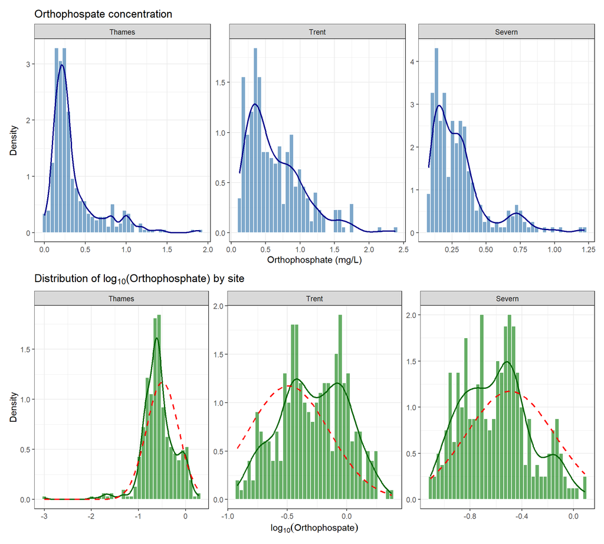

```r
p_raw <- ggplot(df_used, aes(x = result)) +
  geom_histogram(aes(y = after_stat(density)),
                 bins = 40, fill = "steelblue", alpha = 0.7, colour = "white") +
  geom_density(colour = "darkblue", linewidth = 0.8) +
  facet_wrap(~site_short, scales = "free", ncol = 3) +
  labs(title = "Orthophospate concentration",
       x = "Orthophosphate (mg/L)", y = "Density") +
  theme_bw()

p_log <- ggplot(df_used, aes(x = log10_conc)) +
  geom_histogram(aes(y = after_stat(density)),
                 bins = 40, fill = "forestgreen", alpha = 0.7, colour = "white") +
  geom_density(colour = "darkgreen", linewidth = 0.8) +
  stat_function(fun = dnorm,
                args = list(mean = mean(df_used$log10_conc),
                            sd   = sd(df_used$log10_conc)),
                colour = "red", linetype = "dashed", linewidth = 0.8) +
  facet_wrap(~site_short, scales = "free", ncol = 3) +
  labs(title = expression("Distribution of " * log[10] *
                            "(Orthophosphate) by site"),
       x = expression(log[10](Orthophospate)), y = "Density") +
  theme_bw()

p_raw / p_log #combine the plot
```

```r
ggsave("output_img/vers15_eda_raw_vs_log10.png", width = 10, height = 6, dpi = 150)
```

## 3.2 Q-Q Plot

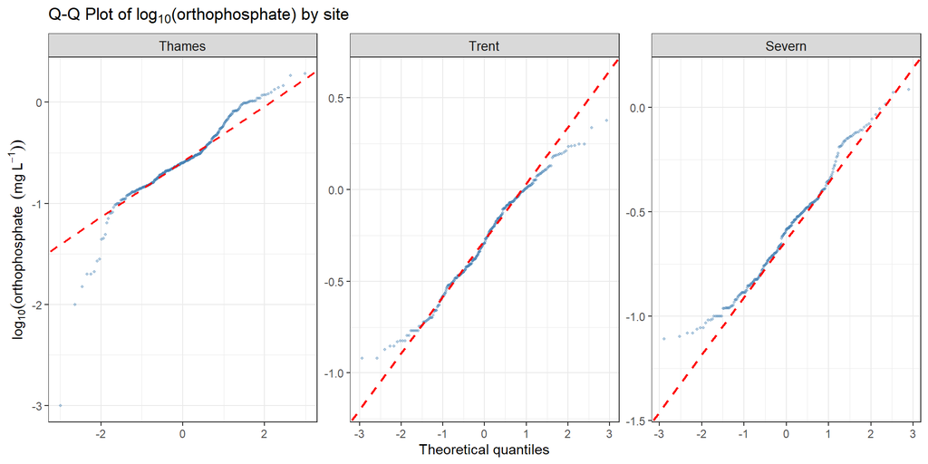

```r
ggplot(df_used, aes(sample = log10_conc)) +
  stat_qq(colour = "steelblue", alpha = 0.4, size = 0.8) +
  stat_qq_line(colour = "red", linetype = "dashed", linewidth = 0.8) +
  facet_wrap(~site_short, scales = "free", ncol = 3) +
  labs(title    = expression("Q-Q Plot of " * log[10]*"(orthophosphate) by site"),
       x = "Theoretical quantiles",
       y = expression(log[10](orthophosphate~~(mg~L^{-1})))) +
  theme_bw() +
  theme(strip.text = element_text(size = 10))
```

```r
ggsave("output_img/vers15_qqplot_log10.png", width = 10, height = 4, dpi = 150)
```

## 3.3 Concentration vs Flow

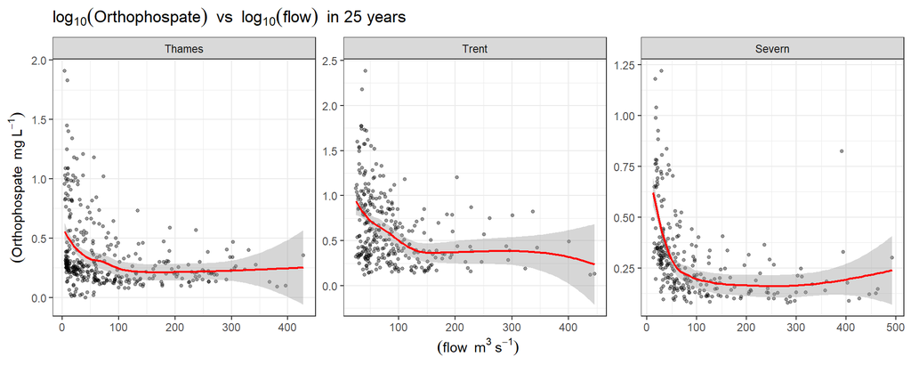

```r
# plotting between concentration vs flow
ggplot(df_used, aes(x = flow, y = result)) +
  geom_point(alpha = 0.4, size = 1) +
  geom_smooth(method = "loess", se = TRUE, colour = "red", linewidth = 0.8) +
  facet_wrap(~site_short, scales = "free") +
  labs(title = expression(log[10](Orthophospate)~~"vs"~~log[10](flow)~~"in 25 years"),
       x = expression((flow~~m^3~s^{-1})),
       y = expression((Orthophospate~~mg~L^{-1}))) +
  theme_bw()
```

```r
ggsave("output_img/vers15_lam_eda_scatter.png", width = 10, height = 4, dpi = 150)
```

## 3.4 Seasonal Flow-Concentration

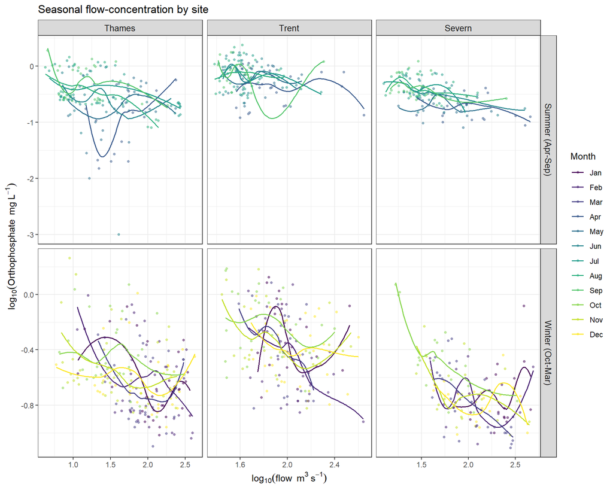

```r
# checking seasonality in seasonal-flow concentration
ggplot(df_used,
       aes(x = log10_flow, y = log10_conc, colour = factor(month))) +
  geom_point(alpha = 0.5, size = 1) +
  geom_smooth(method = "loess", se = FALSE, linewidth = 0.6) +
  facet_grid(
    ifelse(month %in% c(10, 11, 12, 1, 2, 3),
           "Winter (Oct-Mar)", "Summer (Apr-Sep)") ~ site_short,
    scales = "free"
  )+
  scale_colour_viridis_d(
    name   = "Month",
    labels = c("1" = "Jan", "2" = "Feb", "3" = "Mar", "4" = "Apr",
               "5" = "May", "6" = "Jun", "7" = "Jul", "8" = "Aug",
               "9" = "Sep", "10" = "Oct", "11" = "Nov", "12" = "Dec")
  ) +
  labs(title = "Seasonal flow-concentration by site",
       x = expression(log[10](flow~~m^3~s^{-1})),
       y = expression(log[10](Orthophosphate~~mg~L^{-1}))) +
  theme_bw() + theme(strip.text = element_text(size = 10))
```

```r
ggsave("output_img/vers15_lam_eda_seasonal.png", width = 10, height = 6, dpi = 150)
```

## 3.5 Concentration-Flow Relationship by Period

Shifting loess curves across periods indicate that B(t) and D(t) are not constant — this motivates the time-varying extensions M2 and M3.

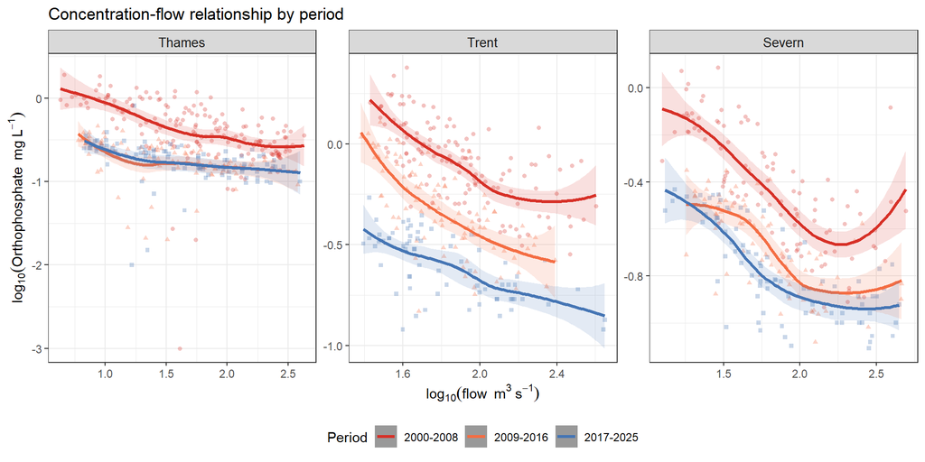

```r
df_used %>%
  mutate(era = case_when(
    year(date) < 2009 ~ "2000-2008",
    year(date) < 2017 ~ "2009-2016",
    TRUE ~ "2017-2025" #others
  )) %>%
  ggplot(aes(x = log10_flow, y = log10_conc, colour = era)) +
  geom_point(aes(shape = era), alpha = 0.3, size = 1.2) +
  geom_smooth(aes(fill = era), method = "loess",
              se = TRUE, linewidth = 1.2, alpha = 0.15) +
  scale_colour_manual(name   = "Period",
                      values = c("2000-2008" = "#d73027",
                                 "2009-2016" = "#f46d43",
                                 "2017-2025" = "#4575b4")) +
  scale_fill_manual(name   = "Period",
                    values = c("2000-2008" = "#d73027",
                               "2009-2016" = "#f46d43",
                               "2017-2025" = "#4575b4")) +
  scale_shape_manual(name   = "Period",
                     values = c("2000-2008" = 16,
                                "2009-2016" = 17,
                                "2017-2025" = 15)) +
  facet_wrap(~site_short, ncol = 3, scales = "free") +
  labs(title = "Concentration-flow relationship by period",
       x = expression(log[10](flow~~m^3~s^{-1})),
       y = expression(log[10](Orthophosphate~~mg~L^{-1}))) +
  theme_bw() +
  guides(colour = guide_legend(override.aes = list(alpha = 1, size = 3)),
         fill = "none") +
  theme(legend.position = "bottom") + theme(strip.text = element_text(size = 10))
```

```r
ggsave("output_img/vers15_eda_era_comparison.png",
       width = 13, height = 4, dpi = 150)
```

# 4 Model Formulas and Priors

All three models share the same LAM mean function derived from Bowes et al. (2008):

$$\mu_i = \log_{10}\!\left(10^{\log A +
(B-1)\log_{10}Q_i} + 10^{\log E + (D-1)\log_{10}Q_i}\right)$$

with Student-t likelihood and left-censoring via `cens(cens_flag)`.

## 4.1 M1, Static LAM

```r
formula_m1 <- bf(
  log10_conc | cens(cens_flag) ~
    log10(10^(logA + (B - 1) * log10_flow) + 10^(logE + (D - 1) * log10_flow)),
  logA ~ 1, B ~ 1, logE ~ 1, D ~ 1,
  nl = TRUE
)

priors_m1 <- c(
  prior(normal(-0.5, 0.5), nlpar = "logA"),          # A ≈ 0.3 mg/L
  prior(normal( 0.0, 0.3), nlpar = "B",    ub = 1),  # B < 1 → dilution
  prior(normal(-1.5, 0.5), nlpar = "logE"),           # C' ≈ 0.03 mg/L
  prior(normal( 1.5, 0.3), nlpar = "D",    lb = 1),  # D > 1 → enrichment
  prior(gamma(2, 0.1), class = "nu")              # Student-t df
)

# Starting values at expected LAM parameter values
init_m1 <- replicate(4,
  list(logA = -0.5, B = 0.0, logE = -1.5, D = 1.5, nu = 5),
  simplify = FALSE)
```

## 4.2 M2, Time-varying LAM

B(t) and D(t) drift smoothly via thin-plate splines with k=6 basis functions

```r
formula_m2 <- bf(
  log10_conc | cens(cens_flag) ~
    log10(10^(logA + (B - 1) * log10_flow) + 10^(logE + (D - 1) * log10_flow)),
  logA ~ 1,
  B    ~ s(time_index, k = 6),
  logE ~ 1,
  D    ~ s(time_index, k = 6),
  nl = TRUE
)

priors_m2 <- c(
  prior(normal(-0.5, 0.5), nlpar = "logA"),
  prior(normal( 0.0, 0.5), nlpar = "B",    ub = 1),
  prior(normal(-1.5, 0.5), nlpar = "logE"),
  prior(normal( 1.5, 0.3), nlpar = "D",    lb = 1),
  prior(normal(0, 0.5), nlpar = "B",    class = "sds", lb = 0),
  prior(normal(0, 0.5), nlpar = "D",    class = "sds", lb = 0),
  prior(gamma(2, 0.1), class = "nu")
)

init_m2 <- replicate(4,
  list(logA = -0.5, B = 0.0, logE = -1.5, D = 1.5, nu = 5),
  simplify = FALSE)
```

## 4.3 M3, Seasonal adjustment + Time-varying LAM

Extends M2 by adding a cyclic cubic spline for calendar month.

```r
formula_m3 <- bf(
  log10_conc | cens(cens_flag) ~
    log10(10^(logA + (B - 1) * log10_flow) + 10^(logE + (D - 1) * log10_flow)) + seas,
  logA ~ 1,
  B ~ s(time_index, k = 6),
  logE ~ 1,
  D ~ s(time_index, k = 6),
  seas ~ s(month, bs = "cc", k = 6),  # cyclic, Jan joins Dec smoothly
  nl = TRUE
)

priors_m3 <- c(
  prior(normal(-0.5, 0.5), nlpar = "logA"),
  prior(normal( 0.0, 0.5), nlpar = "B",    ub = 1),
  prior(normal(-1.5, 0.5), nlpar = "logE"),
  prior(normal( 1.5, 0.3), nlpar = "D",    lb = 1),
  prior(normal( 0.0, 0.3), nlpar = "seas"),  # seasonal centred at 0
  prior(normal(0, 0.5), nlpar = "B", class = "sds", lb = 0),
  prior(normal(0, 0.5), nlpar = "D",class = "sds", lb = 0),
  prior(normal(0, 0.5), nlpar = "seas",class = "sds", lb = 0),
  prior(gamma(2, 0.1), class = "nu")
)

init_m3 <- replicate(4,
  list(logA = -0.5, B = 0.0, logE = -1.5, D = 1.5, seas = 0.0, nu = 5),
  simplify = FALSE)
```

## 4.4 Helper: Fit One Model for One Site

```r
# Helper function
# fitting model use brms with given information (in argument)
fit_lam <- function(formula, prior, init, data, site, model_label,
                    adapt_delta = 0.999, treedepth = 15,
                    iter = 10000, warmup = 4000) {

  brm(
    formula = formula,
    data    = data,
    family  = student(),
    prior   = prior,
    chains  = 4,
    iter    = iter,
    warmup  = warmup,
    thin    = 2,
    cores   = 4,
    seed    = 42,
    init    = init,
    control = list(adapt_delta   = adapt_delta,
                   max_treedepth = treedepth),
    file    = paste0("rds_file/vers16_lam_", tolower(site), "_", model_label)
  )
}
```

# 5 Fit All Models

fit all models with helper function

```r
sites <- c("Thames", "Trent", "Severn")

# Split data by site
site_data <- split(df_used, df_used$site_short)

# bseline static model
fits_m1 <- vector("list", 3L); names(fits_m1) <- sites
for (s in sites) {
  fits_m1[[s]] <- fit_lam(formula_m1, priors_m1, init_m1,
                           data = site_data[[s]], site = s, model_label = "m1",
                           adapt_delta = 0.99, treedepth = 12,
                           iter = 8000, warmup = 2000)
}

# time-varying parameter
fits_m2 <- vector("list", 3L); names(fits_m2) <- sites
for (s in sites) {
  fits_m2[[s]] <- fit_lam(formula_m2, priors_m2, init_m2,
                           data = site_data[[s]], site = s, model_label = "m2")
}

# seasonal + time-varying
fits_m3 <- vector("list", 3L); names(fits_m3) <- sites
for (s in sites) {
  fits_m3[[s]] <- fit_lam(formula_m3, priors_m3, init_m3,
                           data = site_data[[s]], site = s, model_label = "m3")
}
```

# 6 Model Comparison

## 6.1 LOO-CV

Rule: |elpd_diff / se_diff| > 4 means meaningful improvement.

```r
for (s in sites) {
  fits_m1[[s]] <- add_criterion(fits_m1[[s]], "loo")
  fits_m2[[s]] <- add_criterion(fits_m2[[s]], "loo")
  fits_m3[[s]] <- add_criterion(fits_m3[[s]], "loo")
}

loo_results <- bind_rows(lapply(sites, function(s) {
  get_loo <- function(fit, label) {
    l <- fit$criteria$loo
    tibble(model  = label,
           elpd_loo = l$estimates["elpd_loo", "Estimate"],
           p_loo  = l$estimates["p_loo", "Estimate"],
           se_loo  = l$estimates["elpd_loo", "SE"])
  }
  bind_rows(
    get_loo(fits_m1[[s]],"M1: Basic"),
    get_loo(fits_m2[[s]],"M2: Time-varying"),
    get_loo(fits_m3[[s]],"M3: Seasonal+Time")
  ) %>% mutate(site = s, delta_elpd = elpd_loo - max(elpd_loo)) %>%
    arrange(desc(elpd_loo))
}))

print(loo_results)
```

```
## # A tibble: 9 × 6
##   model             elpd_loo p_loo se_loo site   delta_elpd
##   <chr>                <dbl> <dbl>  <dbl> <chr>       <dbl>
## 1 M3: Seasonal+Time    205.  19.0   26.0  Thames        0
## 2 M2: Time-varying     167.  14.7   25.3  Thames      -37.8
## 3 M1: Basic            -98.7  6.07  19.8  Thames     -303.
## 4 M3: Seasonal+Time    251.  14.8   14.2  Trent         0
## 5 M2: Time-varying     230.  11.2   15.0  Trent       -20.9
## 6 M1: Basic            -26.3  3.08   9.78 Trent      -277.
## 7 M3: Seasonal+Time    209.  16.8   14.2  Severn        0
## 8 M2: Time-varying     165.  11.6   14.0  Severn      -44.0
## 9 M1: Basic             42.5  4.07  11.5  Severn     -166.
```

```r
# Significance ratios
cat("\n|elpd_diff / se_diff| per site (> 4 = meaningful):\n")
```

```
##
## |elpd_diff / se_diff| per site (> 4 = meaningful):
```

```r
for (s in sites) {
  cmp    <- loo_compare(fits_m1[[s]], fits_m2[[s]], fits_m3[[s]], criterion = "loo")
  ratios <- abs(cmp[, "elpd_diff"] / cmp[, "se_diff"])
  cat(sprintf("  %s: M3 vs M2 = %.2f | M3 vs M1 = %.2f\n",
              s, ratios[2], ratios[3]))
}
```

```
##   Thames: M3 vs M2 = 4.33 | M3 vs M1 = 16.56
##   Trent: M3 vs M2 = 3.35 | M3 vs M1 = 19.63
##   Severn: M3 vs M2 = 4.93 | M3 vs M1 = 13.70
```

# 7 Checking the Model

## 7.1 Trace Plots for Convergence

```r
for (s in sites) {
  pars_key <- intersect(
    c("b_logA_Intercept", "b_B_Intercept",
      "b_logE_Intercept", "b_D_Intercept", "nu"),
    variables(fits_m3[[s]])
  )
  p <- mcmc_trace(
    as_draws_array(fits_m3[[s]]),
    pars = pars_key,
    facet_args = list(ncol = 1, strip.position = "left")
  ) +
    labs(title = sprintf("Trace plot — %s | Final Model", s)) +
    theme_bw(base_size = 9)

  ggsave(
    filename = sprintf("output_img/ver15_trace_%s.png", s), plot = p, width = 8,
    height = 10,dpi = 300
  )
}
```

## 7.2 Posterior Predictive Check

We draw 200 replicated datasets from M3 and compare their density to the observed log₁₀(ortho-P). Coverage at 50% and 95% confirms model calibration.

```r
ppc_plots <- list()

for (s in sites) {
  y <- fits_m3[[s]]$data$log10_conc
  yrep <- posterior_predict(fits_m3[[s]], ndraws = 200, seed = 42)

  ppc_plots[[s]] <- ppc_dens_overlay(y, yrep[1:50, ]) +
    labs(title = s) +
    theme_bw()

  cov50 <- mean(y >= apply(yrep, 2, quantile, 0.25) &
                y <= apply(yrep, 2, quantile, 0.75))
  cov95 <- mean(y >= apply(yrep, 2, quantile, 0.025) &
                y <= apply(yrep, 2, quantile, 0.975))
  cat(sprintf("[%s | M3] 50%% coverage: %.1f%% | 95%% coverage: %.1f%%\n",
              s, 100 * cov50, 100 * cov95))
}
```

```
## [Thames | M3] 50% coverage: 52.4% | 95% coverage: 94.2%
## [Trent | M3] 50% coverage: 49.8% | 95% coverage: 96.7%
## [Severn | M3] 50% coverage: 54.8% | 95% coverage: 96.2%
```

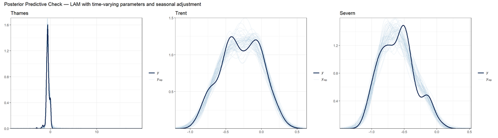

```r
combined <- wrap_plots(ppc_plots, ncol = 3) +
  plot_annotation(
    title = "Posterior Predictive Check — LAM with time-varying parameters and seasonal adjustment"
  )

print(combined)
```

```r
ggsave("output_img/vers15_ppc_m3_combined.png",
       plot = combined, width = 18, height = 5, dpi = 150)
```

## 7.3 Checking Residuals

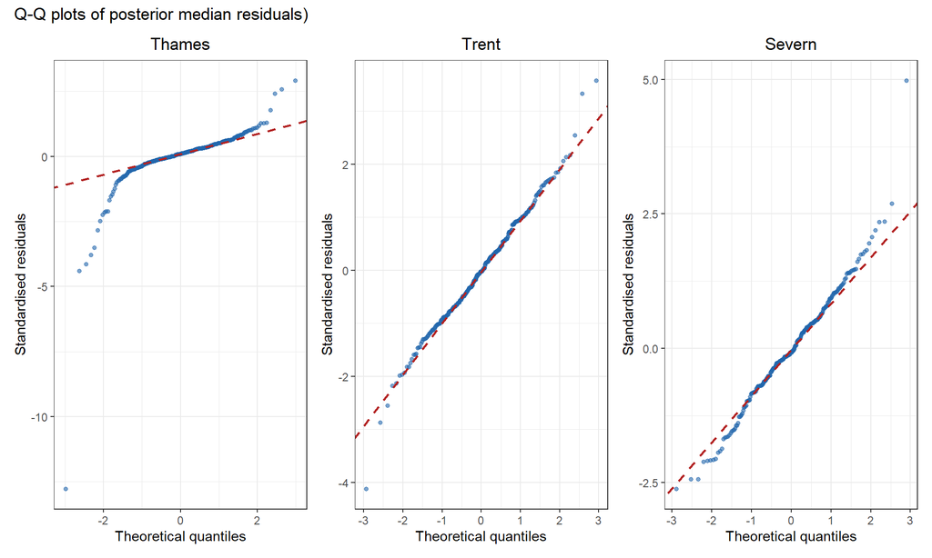

```r
# Compute residuals manually for each site
qq_plots <- lapply(sites, function(s) {

  fit <- fits_m3[[s]]
  data <- site_data[[s]]

  # posterior median fitted values on log10 scale
  fitted_vals <- fitted(fit, summary = TRUE)[, "Estimate"]
  observed <- data$log10_conc
  cens_flag <- data$cens_flag

  res <- observed - fitted_vals

  data.frame(
    residual  = res,
    fitted = fitted_vals,
    observed  = observed,
    cens_flag = cens_flag,
    site = s
  )
})

qq_all <- do.call(rbind, qq_plots)

# Q-Q plots
qq_plot_list <- lapply(sites, function(s) {

  # detected observations only
  r <- qq_all[qq_all$site == s & qq_all$cens_flag == "none", "residual"]

  # standardise
  r_std <- (r - mean(r)) / sd(r)

  ggplot(data.frame(r = r_std), aes(sample = r)) +
    stat_qq(colour = "#2166ac", alpha = 0.6, size = 1.2) +
    stat_qq_line(colour = "firebrick", linetype = "dashed", linewidth = 0.8) +
    labs(
      title = s,
      x = "Theoretical quantiles",
      y = "Standardised residuals"
    ) +
    theme_bw(base_size = 11) +
    theme(plot.title = element_text(hjust = 0.5))
})

combined_qq <- wrap_plots(qq_plot_list, ncol = 3) +
  plot_annotation(
    title   = "Q-Q plots of posterior median residuals)"
  )

print(combined_qq)
```

```r
ggsave("output_img/ver15_qq_residuals_m3.png", plot = combined_qq,
       width = 12, height = 4.5, dpi = 300)
```

# 8 Final Model Summary

```r
fits_m3
```

```
## $Thames
##  Family: student
##   Links: mu = identity
## Formula: log10_conc | cens(cens_flag) ~ log10(10^(logA + (B - 1) * log10_flow) + 10^(logE + (D - 1) * log10_flow)) + seas
##          logA ~ 1
##          B ~ s(time_index, k = 6)
##          logE ~ 1
##          D ~ s(time_index, k = 6)
##          seas ~ s(month, bs = "cc", k = 6)
##    Data: data (Number of observations: 361)
##   Draws: 4 chains, each with iter = 10000; warmup = 4000; thin = 2;
##          total post-warmup draws = 12000
##
## Smoothing Spline Hyperparameters:
##                      Estimate Est.Error l-95% CI u-95% CI Rhat Bulk_ESS
## sds(B_stime_index_1)     0.86      0.23     0.50     1.37 1.00     9333
## sds(D_stime_index_1)     0.59      0.19     0.31     1.06 1.00     7029
## sds(seas_smonth_1)       0.05      0.03     0.02     0.13 1.00     5793
##                      Tail_ESS
## sds(B_stime_index_1)    10488
## sds(D_stime_index_1)     9140
## sds(seas_smonth_1)       8575
##
## Regression Coefficients:
##                 Estimate Est.Error l-95% CI u-95% CI Rhat Bulk_ESS Tail_ESS
## logA_Intercept      0.06      0.23    -0.39     0.51 1.00     8656     9786
## B_Intercept        -0.05      0.07    -0.19     0.07 1.00    10979    10553
## logE_Intercept     -1.16      0.23    -1.61    -0.71 1.00     8913     9801
## D_Intercept         1.01      0.01     1.00     1.02 1.00    10102     8797
## seas_Intercept      0.32      0.23    -0.13     0.77 1.00     8772     9719
## B_stime_index_1    -0.76      0.40    -1.53     0.03 1.00    10258     9011
## D_stime_index_1     1.22      0.17     1.01     1.63 1.00     9568     8043
##
## Further Distributional Parameters:
##       Estimate Est.Error l-95% CI u-95% CI Rhat Bulk_ESS Tail_ESS
## sigma     0.07      0.01     0.06     0.08 1.00    10369    11072
## nu        1.77      0.22     1.39     2.23 1.00    10466    10552
##
## Draws were sampled using sampling(NUTS). For each parameter, Bulk_ESS
## and Tail_ESS are effective sample size measures, and Rhat is the potential
```

[output cut: 70 more lines]

```
## B_Intercept         0.47      0.05     0.36     0.57 1.00     8019     9763
## logE_Intercept     -1.86      0.35    -2.58    -1.21 1.00     9615    10544
## D_Intercept         1.18      0.12     1.01     1.44 1.00     9270     8836
## seas_Intercept      0.09      0.24    -0.40     0.56 1.00    10352    10421
## B_stime_index_1    -0.68      0.25    -1.16    -0.18 1.00    10076     8846
## D_stime_index_1     1.42      0.25     1.03     1.97 1.00     7956     6620
##
## Further Distributional Parameters:
##       Estimate Est.Error l-95% CI u-95% CI Rhat Bulk_ESS Tail_ESS
## sigma     0.10      0.01     0.08     0.11 1.00     9229    10790
## nu       14.13      8.74     4.86    37.40 1.00    10189    10810
##
## Draws were sampled using sampling(NUTS). For each parameter, Bulk_ESS
## and Tail_ESS are effective sample size measures, and Rhat is the potential
## scale reduction factor on split chains (at convergence, Rhat = 1).
```

# 9 Daily Predictions from final model

## 9.1 Daily Prediction for Concentration at Observed Flow value

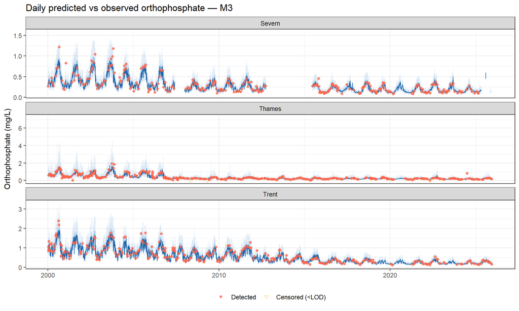

```r
# Step 1: Get site-specific time_index origin from fitting data
site_origins <- df_used %>%
  group_by(site_short) %>%
  summarise(origin_date = min(date), .groups = "drop")

# Step 2: Build full daily prediction grid from flow_clean
# This uses ALL daily flow rows (not just observed concentration days)
sites_keep <- c("THAMES AT TEDDINGTON WEIR",
                "TIDAL TRENT - RIVER TRENT AT DUNHAM",
                "RIVER SEVERN (LOWER) HAW BRIDGE")

df_daily_all <- flow_clean %>%
  filter(wq_site_name %in% sites_keep, flow > 0, !is.na(flow)) %>%
  mutate(
    site_short = case_when(
      wq_site_name == "THAMES AT TEDDINGTON WEIR"           ~ "Thames",
      wq_site_name == "TIDAL TRENT - RIVER TRENT AT DUNHAM" ~ "Trent",
      wq_site_name == "RIVER SEVERN (LOWER) HAW BRIDGE"     ~ "Severn"
    ),
    site_short = factor(site_short, levels = c("Thames", "Trent", "Severn")),
    month = month(date),
    log10_flow = log10(flow),
    cens_flag = "none"
  ) %>%
  left_join(site_origins, by = "site_short") %>%
  mutate(
    # Same origin as fitting data
    time_index = as.numeric(date - origin_date) / 365.25
  ) %>%
  select(-origin_date)

# Step 3: Split by site
flow_daily_list_full <- split(df_daily_all, df_daily_all$site_short)

# Get full posterior draws for all days (not just median_qi summary)
pred_draws_full <- bind_rows(
  lapply(sites, function(s) {
    add_predicted_draws(
      newdata = flow_daily_list_full[[s]],
      object = fits_m3[[s]],
      ndraws = 300,
      seed = 42
    ) %>%
      mutate(
        pred_mgL = 10^.prediction,
        site_short = factor(s, levels = c("Thames", "Trent", "Severn"))
      )
  })
)

# Summarise: median and intervals from predicted draws
pred_summary <- pred_draws_full %>%
  group_by(site_short, date) %>%
  median_qi(pred_mgL, .width = c(0.50, 0.95)) %>%
  ungroup()

# Join observed
pred_summary <- pred_summary %>%
  mutate(site_short = as.character(site_short)) %>%
  left_join(
    df_used %>%
      mutate(site_short = as.character(site_short)) %>%
      select(site_short, date, obs_conc = result, censored),
    by = c("site_short", "date")
  )

# Gap-fill for geom_line
pred_summary_line <- pred_summary %>%
  filter(.width == 0.50) %>%
  group_by(site_short) %>%
  complete(date = seq(min(date), max(date), by = "day")) %>%
  ungroup()

# Gap-fill for both line and ribbon
pred_summary_gapfilled <- pred_summary %>%
  group_by(site_short, .width) %>%
  complete(date = seq(min(date), max(date), by = "day")) %>%
  ungroup()

ggplot() +
  geom_ribbon(
    data = pred_summary_gapfilled %>% filter(.width == 0.95),
    aes(x = date, ymin = .lower, ymax = .upper),
    fill = "#a8c8e8", alpha = 0.4
  ) +
  geom_ribbon(
    data = pred_summary_gapfilled %>% filter(.width == 0.50),
    aes(x = date, ymin = .lower, ymax = .upper),
    fill = "#5599cc", alpha = 0.5
  ) +
  geom_line(
    data      = pred_summary_gapfilled %>% filter(.width == 0.50),
    aes(x = date, y = pred_mgL),
    colour    = "#2266aa",
    linewidth = 0.4,
    na.rm     = FALSE
  ) +
  geom_point(
    data = pred_summary %>% filter(.width == 0.50, !is.na(obs_conc)),
    aes(x = date, y = obs_conc, colour = censored, shape = censored),
    size = 1.5, alpha = 0.8
  ) +
  scale_colour_manual(
    values = c("FALSE" = "tomato", "TRUE" = "orange"),
    labels = c("Detected", "Censored (<LOD)")
  ) +
  scale_shape_manual(
    values = c("FALSE" = 16, "TRUE" = 6),
    labels = c("Detected", "Censored (<LOD)")
  ) +
  facet_wrap(~site_short, ncol = 1, scales = "free_y") +
  labs(
    title    = "Daily predicted vs observed orthophosphate — M3",
    x = NULL, y = "Orthophosphate (mg/L)",
    colour = NULL, shape = NULL
  ) +
  theme_bw() +
  theme(legend.position = "bottom")
```

```r
ggsave("output_img/vers15_daily_pred_m3_alldays.png", width = 14, height = 8, dpi = 150)
```

## 9.2 Concentration vs Flow (Daily Conc from Fitted Model)

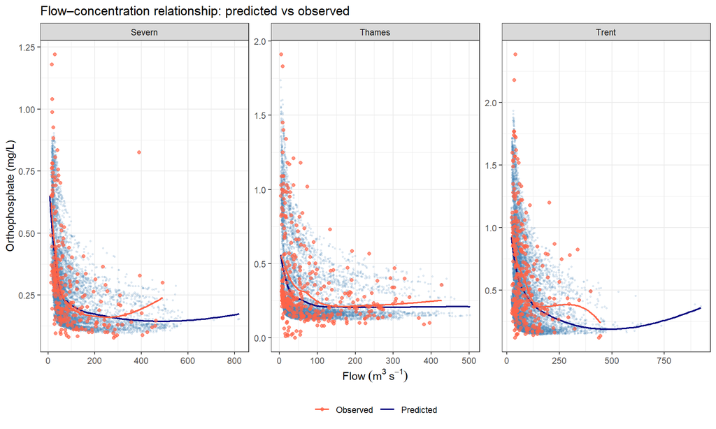

```r
# Save joined data first to avoid repeating the join
pred_summary_flow <- pred_summary %>%
  left_join(
    df_daily_all %>% select(site_short, date, flow, log10_flow),
    by = c("site_short", "date")
  )

pred_summary_flow %>%
  filter(.width == 0.50) %>%
  ggplot(aes(x = flow, y = pred_mgL)) +
  # all daily predicted (background)
  geom_point(
    alpha = 0.15, size = 0.5, colour = "steelblue"
  ) +
  geom_smooth(
    aes(colour = "Predicted"),
    method = "loess", se = FALSE, linewidth = 0.8
  ) +
  # observed on sampled days (foreground)
  geom_point(
    data = pred_summary_flow %>% filter(.width == 0.50, !is.na(obs_conc)),
    aes(x = flow, y = obs_conc, colour = "Observed"),
    size = 1.5, alpha = 0.7
  ) +
  geom_smooth(
    data   = pred_summary_flow %>% filter(.width == 0.50, !is.na(obs_conc)),
    aes(x = flow, y = obs_conc, colour = "Observed"),
    method = "loess", se = FALSE, linewidth = 0.8
  ) +
  scale_colour_manual(
    values = c("Predicted"="navy", "Observed" = "tomato")
  ) +
  facet_wrap(~site_short, scales = "free") +
  labs(
    title = "Flow–concentration relationship: predicted vs observed",
    x = expression(Flow~(m^3~s^{-1})),
    y = "Orthophosphate (mg/L)",
    colour = NULL
  ) +
  theme_bw() +
  theme(legend.position = "bottom")
```

```r
ggsave("output_img/vers15_lam_eda_scatter_predict.png", width = 10, height = 4, dpi = 150)
```

## 9.3 Time-varying Exponents B(t) and D(t)

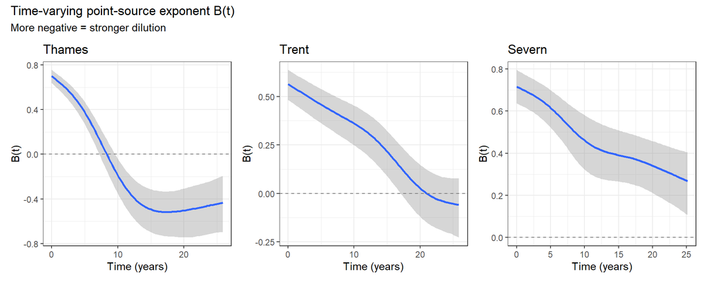

```r
B_plots <- lapply(sites, function(s) {
  plot(conditional_effects(fits_m3[[s]], effects = "time_index",
                           nlpar = "B", re_formula = NA),
       plot = FALSE)[[1]] +
    labs(title = s, x = "Time (years)", y = "B(t)") +
    geom_hline(yintercept = 0, linetype = "dashed", colour = "grey50") +
    theme_bw()
})

D_plots <- lapply(sites, function(s) {
  plot(conditional_effects(fits_m3[[s]], effects = "time_index",
                           nlpar = "D", re_formula = NA),
       plot = FALSE)[[1]] +
    labs(title = s, x = "Time (years)", y = "D(t)") +
    geom_hline(yintercept = 1, linetype = "dashed", colour = "grey50") +
    theme_bw()
})

wrap_plots(B_plots, ncol = 3) +
  plot_annotation(title = "Time-varying point-source exponent B(t)",
                  subtitle = "More negative = stronger dilution")
```

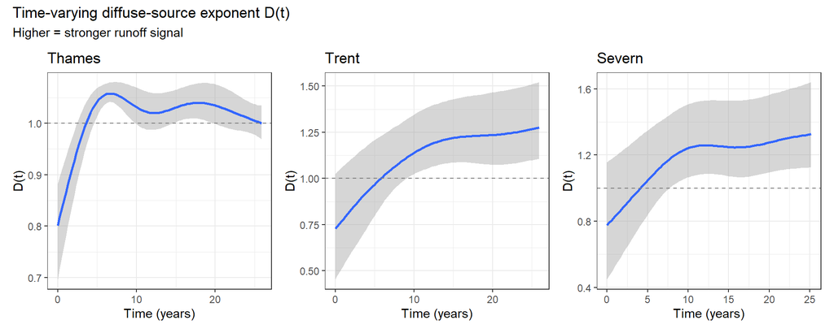

```r
ggsave("output_img/vers15_b over time.png",
       width = 13, height = 4, dpi = 150)

wrap_plots(D_plots, ncol = 3) +
  plot_annotation(title = "Time-varying diffuse-source exponent D(t)",
                  subtitle = "Higher = stronger runoff signal")
```

```r
ggsave("output_img/vers15_d over time.png",
       width = 13, height = 4, dpi = 150)
```

# 10 Source Apportionment

## 10.1 Percentage Contribution by Flow

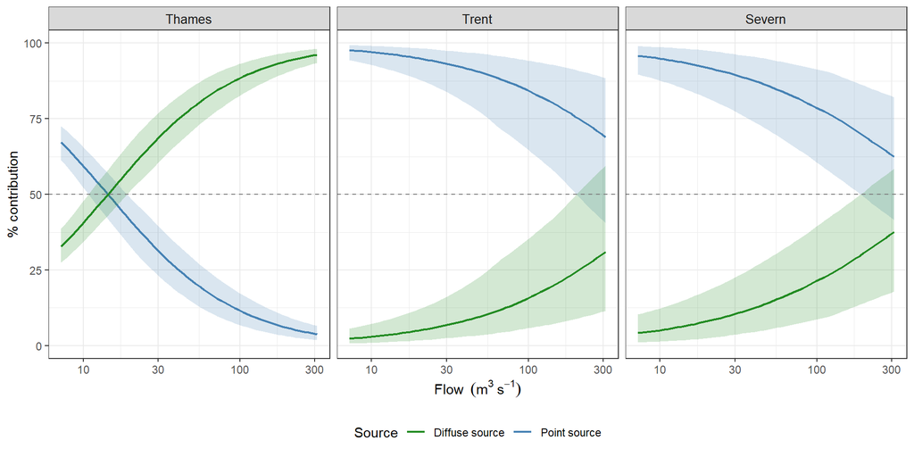

```r
apportionment <- function(fit, newflow, ndraws = 500) {
  set.seed(42)
  draws <- as_draws_df(fit) %>% slice_sample(n = ndraws)
  map_dfr(newflow, function(q) {
    log10q <- log10(q)
    pt  <- 10^(draws$b_logA_Intercept + (draws$b_B_Intercept-1) * log10q)
    dif <- 10^(draws$b_logE_Intercept + (draws$b_D_Intercept-1) * log10q)
    tibble(flow = q,
           point_source = pt,
           diffuse_source = dif,
           pct_point = 100*pt  / (pt + dif),
           pct_diffuse= 100*dif / (pt + dif))
  })
}

# Global flow range across all sites
global_flow_min <- min(sapply(sites, function(s)
  quantile(site_data[[s]]$flow, 0.05)))
global_flow_max <- max(sapply(sites, function(s)
  quantile(site_data[[s]]$flow, 0.95)))

flow_grid <- 10^seq(log10(global_flow_min),
                    log10(global_flow_max),
                    length.out = 60)

apportion_all <- bind_rows(lapply(sites, function(s) {
  apportionment(fits_m3[[s]], flow_grid) %>%
    group_by(flow) %>%
    summarise(across(c(pct_point, pct_diffuse),
                     list(median = median,
                          lo95 = ~quantile(., 0.025),
                          hi95 = ~quantile(., 0.975)),
                     .names = "{.col}_{.fn}"),
              .groups = "drop") %>%
    mutate(site = factor(s, levels = c("Thames", "Trent", "Severn")))
}))

ggplot(apportion_all, aes(x = flow)) +
  geom_ribbon(aes(ymin = pct_point_lo95,   ymax = pct_point_hi95),
              fill = "steelblue", alpha = 0.2) +
  geom_line(aes(y = pct_point_median,   colour = "Point source"),
            linewidth = 0.8) +
  geom_ribbon(aes(ymin = pct_diffuse_lo95, ymax = pct_diffuse_hi95),
              fill = "forestgreen", alpha = 0.2) +
  geom_line(aes(y = pct_diffuse_median, colour = "Diffuse source"),
            linewidth = 0.8) +
  geom_hline(yintercept = 50, linetype = "dashed", colour = "grey50") +
  scale_colour_manual(name   = "Source",
                      values = c("Point source"   = "steelblue",
                                 "Diffuse source" = "forestgreen")) +
  scale_x_log10() +
  facet_wrap(~site, ncol = 3) +
  labs(x = expression(Flow~~(m^3~s^{-1})),
       y = "% contribution") +
  theme_bw() +
  theme(legend.position = "bottom")+theme(strip.text = element_text(size = 10))
```

```r
ggsave("output_img/vers15_appor1.png", width = 10, height = 4, dpi = 150)
```

## 10.2 Apportionment at Specific Time Points (Final Model)

```r
# years at which we want to evaluate source apportionment
years_eval <- c(2000, 2005, 2010, 2015, 2020, 2025)
# Map season names to their representative month numbers (July= summer, January = winter)
seasons <- list(summer = 7, winter = 1)  # July = summer, January = winter


# Helper function
# For a given fitted model (fit) and site, compute the point-source vs.
# diffuse-source % contributions to orthophosphate at each combination of
# year and season, evaluated at the median flow for that season/period
apportion_timepoint_season <- function(fit, site_name, data, daily_data, years, seasons) {
  min_date <- min(data$date)

  #iterate over each evaluation year
  bind_rows(lapply(years, function(yr) {
    #iterate over each season
    bind_rows(lapply(names(seasons), function(season_name) {
      month_val <- seasons[[season_name]]

      # Compute median flow for each season
      # Use ±2-year window around the focal year so the flow value is
      # representative of conditions at that point in time, not the full record
      med_flow <- daily_data %>%
        filter(
          month(date) == month_val,
          year(date) >= yr-2,
          year(date) <= yr+2
        ) %>%
        pull(flow) %>%
        median(na.rm = TRUE)

      # if the ±2-year window contains no data (for example, evaluation
      # year is outside the observed record), use the overall seasonal median
      if (is.na(med_flow) | length(med_flow) == 0) {
        med_flow <- daily_data %>%
          filter(month(date) == month_val) %>%
          pull(flow) %>%
          median(na.rm = TRUE)}


      # if there is no data for this month at all, use the
      # grand median across all months and days
      if (is.na(med_flow)) med_flow <- median(daily_data$flow, na.rm = TRUE)

      # generate var
      log10q <- log10(med_flow)

      # Compute the numeric time index
      # Use the 15th of the relevant month as the representative date
      t_id <- as.numeric(
        as.Date(paste0(yr, "-", sprintf("%02d", month_val), "-15")) - min_date
      ) / 365.25

      # Skip this year/season combination if it falls outside the model's
      # training time range (can't sensibly extrapolate)
      if (t_id < 0 | t_id > max(data$time_index)) return(NULL)

      # Step 3: Build the prediction row
      # Take the first row of the site data as a template, then overwrite
      # the covariates we care about; all other columns are structural
      # placeholders that the model formula requires
      newdata <- data %>%
        slice(1) %>%
        mutate(time_index = t_id,
               log10_flow = log10q,
               month = month_val,
               cens_flag= "none")

      # Step 4: Draw posterior samples for the non-linear parameters
      # B controls the flow-scaling exponent for the point-source component
      # (linpred_draws extracts the linear predictor on the log scale)
      set.seed(42)
      B_draws <- linpred_draws(fit, newdata = newdata,
                               nlpar= "B",
                               ndraws = 500,
                               seed = 42)$.linpred

      set.seed(42)
      D_draws <- linpred_draws(fit, newdata = newdata,
                               nlpar= "D",
                               ndraws = 500,
                               seed  = 42)$.linpred

      # Also draw 500 samples from the full posterior to get the intercept
      # parameters (log-scale intercepts for point and diffuse components)
      set.seed(42)
      draws <- as_draws_df(fit) %>% slice_sample(n = 500)

      pt_draws <- 10^(draws$b_logA_Intercept + (B_draws-1) * log10q)
      dif_draws <- 10^(draws$b_logE_Intercept + (D_draws-1) * log10q)
      # Total predicted concentration = point+diffuse
      total <- pt_draws + dif_draws

      tibble(
        year = yr,
        site = site_name,
        season  = season_name,
        flow = round(med_flow, 2),
        conc_median = round(median(total), 3),
        conc_lo = round(quantile(total, 0.025),3),
        conc_hi = round(quantile(total, 0.975),3),
        pct_point = round(100*median(pt_draws/total), 1),
        pct_diffuse = round(100*median(dif_draws/total), 1),
        pt_lo = round(quantile(100*pt_draws/total, 0.025), 1),
        pt_hi = round(quantile(100*pt_draws/total, 0.975), 1),
        dif_lo = round(quantile(100*dif_draws/total, 0.025), 1),
        dif_hi = round(quantile(100*dif_draws/total, 0.975), 1)
      )
    }))
  }))
}

# Run function to every site and store the results into one data frame
apportion_season <- bind_rows(lapply(sites, function(s) {
  apportion_timepoint_season(fits_m3[[s]], s, site_data[[s]],
                             flow_daily_list_full[[s]],
                             years_eval, seasons)
}))


# Summary table with flow and concentration, by season and catchment
apportion_season %>%
  select(site, year, season, flow, conc_median, conc_lo, conc_hi,
         pct_point, pct_diffuse) %>%
  arrange(site, year, season) %>%
  knitr::kable(
  col.names = c("Site", "Year", "Season",
                "Flow (m$^3$/s)",       # LaTeX superscript
                "Conc. median", "l-95% CI", "u-95% CI",
                "% Point", "% Diffuse"),
  caption = "...",
  escape = FALSE
)
```

| Site | Year | Season | Flow (m$^3$/s) | Conc. median | l-95% CI | u-95% CI | % Point | % Diffuse |
| --- | --- | --- | --- | --- | --- | --- | --- | --- |
| Severn | 2000 | summer | 37.54 | 0.459 | 0.165 | 1.495 | 98.5 | 1.5 |
| Severn | 2000 | winter | 125.59 | 0.334 | 0.112 | 1.125 | 98.6 | 1.4 |
| Severn | 2005 | summer | 22.06 | 0.401 | 0.150 | 1.296 | 95.3 | 4.7 |
| Severn | 2005 | winter | 138.14 | 0.224 | 0.077 | 0.738 | 91.3 | 8.7 |
| Severn | 2010 | summer | 40.13 | 0.220 | 0.073 | 0.746 | 81.1 | 18.9 |
| Severn | 2010 | winter | 169.08 | 0.150 | 0.042 | 0.593 | 59.4 | 40.6 |
| Severn | 2015 | summer | 39.35 | 0.186 | 0.061 | 0.626 | 78.6 | 21.4 |
| Severn | 2015 | winter | 57.97 | 0.166 | 0.052 | 0.571 | 72.8 | 27.2 |
| Severn | 2020 | summer | 26.33 | 0.200 | 0.064 | 0.647 | 79.6 | 20.4 |
| Severn | 2020 | winter | 154.36 | 0.120 | 0.029 | 0.565 | 43.5 | 56.5 |
| Severn | 2025 | winter | 176.24 | 0.124 | 0.024 | 0.764 | 26.3 | 73.7 |
| Thames | 2000 | summer | 27.63 | 0.423 | 0.160 | 1.203 | 90.8 | 9.2 |
| Thames | 2005 | summer | 9.79 | 0.317 | 0.126 | 0.874 | 76.0 | 24.0 |
| Thames | 2005 | winter | 99.60 | 0.146 | 0.057 | 0.399 | 43.4 | 56.6 |
| Thames | 2010 | summer | 10.38 | 0.135 | 0.053 | 0.371 | 46.0 | 54.0 |
| Thames | 2010 | winter | 104.16 | 0.085 | 0.033 | 0.237 | 5.4 | 94.6 |
| Thames | 2015 | summer | 14.45 | 0.095 | 0.038 | 0.269 | 21.1 | 78.9 |
| Thames | 2015 | winter | 153.89 | 0.082 | 0.031 | 0.225 | 0.7 | 99.3 |
| Thames | 2020 | summer | 10.26 | 0.109 | 0.041 | 0.300 | 32.1 | 67.9 |
| Thames | 2020 | winter | 105.45 | 0.082 | 0.033 | 0.227 | 1.3 | 98.7 |
| Thames | 2025 | summer | 19.39 | 0.086 | 0.033 | 0.247 | 18.7 | 81.3 |
| Thames | 2025 | winter | 183.35 | 0.071 | 0.027 | 0.190 | 0.9 | 99.1 |
| Trent | 2000 | summer | 43.32 | 0.702 | 0.229 | 2.262 | 99.0 | 1.0 |
| Trent | 2000 | winter | 95.36 | 0.519 | 0.162 | 1.711 | 99.0 | 1.0 |
| Trent | 2005 | summer | 36.40 | 0.534 | 0.172 | 1.675 | 96.6 | 3.4 |
| Trent | 2005 | winter | 115.77 | 0.303 | 0.095 | 1.000 | 94.6 | 5.4 |
| Trent | 2010 | summer | 43.90 | 0.354 | 0.107 | 1.176 | 90.1 | 9.9 |
| Trent | 2010 | winter | 109.13 | 0.225 | 0.066 | 0.730 | 83.0 | 17.0 |
| Trent | 2015 | summer | 40.78 | 0.237 | 0.072 | 0.752 | 81.0 | 19.0 |
| Trent | 2015 | winter | 136.45 | 0.143 | 0.038 | 0.482 | 57.8 | 42.2 |
| Trent | 2020 | summer | 35.03 | 0.160 | 0.043 | 0.516 | 71.1 | 28.9 |
| Trent | 2020 | winter | 117.37 | 0.099 | 0.022 | 0.391 | 37.9 | 62.1 |
| Trent | 2025 | summer | 42.56 | 0.128 | 0.033 | 0.423 | 56.7 | 43.3 |
| Trent | 2025 | winter | 144.09 | 0.094 | 0.019 | 0.471 | 21.5 | 78.5 |

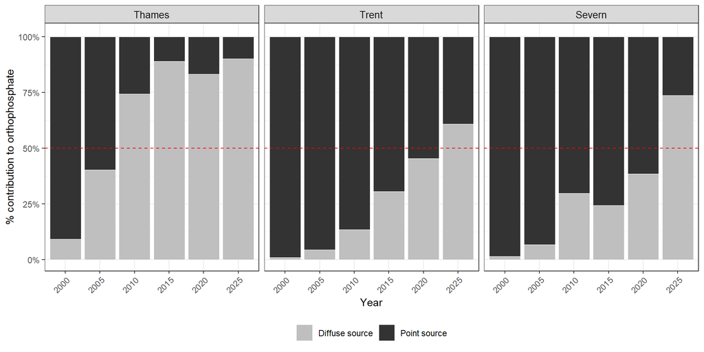

```r
# apportion by sites
apportion_season %>%
  group_by(site, year) %>%
  summarise(
    pct_point   = mean(pct_point,   na.rm = TRUE),
    pct_diffuse = mean(pct_diffuse, na.rm = TRUE),
    .groups = "drop"
  ) %>%
  mutate(
    site = factor(site, levels = c("Thames", "Trent", "Severn")),
    year = factor(year)
  ) %>%
  pivot_longer(cols      = c(pct_point, pct_diffuse),
               names_to  = "source",
               values_to = "pct") %>%
  mutate(source = if_else(source == "pct_point",
                          "Point source", "Diffuse source"),
         source = factor(source,
                         levels = c("Point source", "Diffuse source"))) %>%
  ggplot(aes(x = year, y = pct, fill = source)) +
  geom_col(position = "stack", colour = "white", linewidth = 0.3) +
  geom_hline(yintercept = 50, linetype = "dashed",
             colour = "red", linewidth = 0.4) +
  scale_fill_manual(
    values = c("Point source"   = "grey20",
               "Diffuse source" = "grey75"),
    breaks = c("Diffuse source", "Point source")
  ) +
  scale_y_continuous(labels = scales::percent_format(scale = 1),
                     limits = c(0, 101),
                     breaks = c(0, 25, 50, 75, 100)) +
  facet_wrap(~ site, nrow = 1) +
  labs(x    = "Year",
       y    = "% contribution to orthophosphate",
       fill = NULL) +
  theme_bw() +
  theme(legend.position  = "bottom",
        axis.text.x = element_text(angle = 45, hjust = 1),
        strip.text = element_text(size = 10))
```

```r
ggsave("output_img/apportion_pct.png", width = 10, height = 4, dpi = 150)
```

## 10.3 Parameter Table (Using Model 3)

```r
# years at which we want to evaluate source apportionment
years_show <- c(2000, 2005, 2010, 2015, 2020, 2025)

# Helper function
# everything we want to extract a vector of posterior draws
summarise_param <- function(x) {
  c(
    median = round(median(x),3),
    se= round(sd(x),3),
    lo95 = round(unname(quantile(x,0.025)),3),
    hi95 = round(unname(quantile(x,0.975)),3)
  )
}

m3_timepoints <- bind_rows(lapply(sites, function(s) {

  fit <- fits_m3[[s]]
  min_date <- min(site_data[[s]]$date) #fractional years from first observation

  map_dfr(years_show, function(yr) {

    # pin the evaluation to 1 July, as it's neutral mid-year point that
    # avoids seasonal extremes in either direction
    t_id <- as.numeric(as.Date(paste0(yr, "-07-01")) - min_date) / 365.25

    # hold flow at its median so any change across years reflects the
    # spline trend in B(t)/D(t) rather than a flow effect
    newdata <- data.frame(
      log10_flow= median(fit$data$log10_flow),
      time_index= t_id,
      month = 7,
      cens_flag = "none",
      log10_conc= median(fit$data$log10_conc)
    )

    # A and E are time-invariant intercepts, so just pull them straight
    # from the posterior draws
    set.seed(42)
    draws <- as_draws_df(fit) %>% slice_sample(n=500)
    A_draws  <- 10^draws$b_logA_Intercept
    Cp_draws <- 10^draws$b_logE_Intercept

    # B(t) and D(t) are splines, so we must evaluate them at t_id
    # posterior_epred handles the spline basis internally
    set.seed(42)
    B_draws <- posterior_epred(
      fit,
      newdata = newdata,
      nlpar = "B",
      ndraws= 500
    ) %>% as.vector()

    set.seed(42)
    D_draws <- posterior_epred(
      fit,
      newdata = newdata,
      nlpar = "D",
      ndraws= 500
    ) %>% as.vector()

    # Summarise each parameter
    A_s <- summarise_param(A_draws)
    B_s <- summarise_param(B_draws)
    Cp_s <- summarise_param(Cp_draws)
    D_s <- summarise_param(D_draws)

    tibble(
      Site= s,
      Year = yr,
      A_fmt = sprintf("%.3f (%.3f, %.3f)", A_s[1],A_s[3],A_s[4]),
      B_fmt = sprintf("%.3f (%.3f, %.3f)",B_s[1],B_s[3],B_s[4]),
      Cp_fmt= sprintf("%.3f (%.3f, %.3f)", Cp_s[1],Cp_s[3],Cp_s[4]),
      D_fmt= sprintf("%.3f (%.3f, %.3f)",D_s[1],D_s[3],D_s[4])
    )
  })
}))

# produce tidier table with knitr
m3_timepoints %>%
  knitr::kable(
    caption = "M3 posterior median (95\\% credible interval) at selected
               time points (evaluated at mid-year, July). $A$ and $C'$ in
               mg/L (back-transformed). $B(t)$ and $D(t)$ vary over time
               via penalised regression splines",
    col.names = c("Site","Year",
                  "A (mg/L)", "B(t)", "C' (mg/L)", "D(t)")
  )
```

M3 posterior median (95% credible interval) at selected time points (evaluated at mid-year, July). $A$ and $C'$ in mg/L (back-transformed). $B(t)$ and $D(t)$ vary over time via penalised regression splines

| Site | Year | A (mg/L) | B(t) | C’ (mg/L) | D(t) |
| --- | --- | --- | --- | --- | --- |
| Thames | 2000 | 1.110 (0.451, 3.156) | 0.679 (0.616, 0.732) | 0.069 (0.028, 0.186) | 0.829 (0.741, 0.895) |
| Thames | 2005 | 1.110 (0.451, 3.156) | 0.328 (0.222, 0.427) | 0.069 (0.028, 0.186) | 1.048 (1.026, 1.071) |
| Thames | 2010 | 1.110 (0.451, 3.156) | -0.233 (-0.383, -0.100) | 0.069 (0.028, 0.186) | 1.027 (0.993, 1.063) |
| Thames | 2015 | 1.110 (0.451, 3.156) | -0.509 (-0.715, -0.320) | 0.069 (0.028, 0.186) | 1.032 (1.007, 1.064) |
| Thames | 2020 | 1.110 (0.451, 3.156) | -0.500 (-0.715, -0.320) | 0.069 (0.028, 0.186) | 1.032 (0.997, 1.074) |
| Thames | 2025 | 1.110 (0.451, 3.156) | -0.438 (-0.688, -0.222) | 0.069 (0.028, 0.186) | 1.001 (0.974, 1.035) |
| Trent | 2000 | 3.721 (1.279, 11.886) | 0.552 (0.461, 0.626) | 0.018 (0.004, 0.077) | 0.743 (0.498, 1.078) |
| Trent | 2005 | 3.721 (1.279, 11.886) | 0.446 (0.327, 0.531) | 0.018 (0.004, 0.077) | 0.981 (0.825, 1.253) |
| Trent | 2010 | 3.721 (1.279, 11.886) | 0.347 (0.219, 0.448) | 0.018 (0.004, 0.077) | 1.146 (1.038, 1.366) |
| Trent | 2015 | 3.721 (1.279, 11.886) | 0.197 (0.045, 0.307) | 0.018 (0.004, 0.077) | 1.222 (1.076, 1.432) |
| Trent | 2020 | 3.721 (1.279, 11.886) | 0.013 (-0.160, 0.141) | 0.018 (0.004, 0.077) | 1.233 (1.059, 1.478) |
| Trent | 2025 | 3.721 (1.279, 11.886) | -0.055 (-0.254, 0.073) | 0.018 (0.004, 0.077) | 1.272 (1.083, 1.531) |
| Severn | 2000 | 1.283 (0.507, 4.017) | 0.707 (0.629, 0.784) | 0.015 (0.002, 0.056) | 0.804 (0.466, 1.190) |
| Severn | 2005 | 1.283 (0.507, 4.017) | 0.602 (0.507, 0.681) | 0.015 (0.002, 0.056) | 1.073 (0.885, 1.364) |
| Severn | 2010 | 1.283 (0.507, 4.017) | 0.447 (0.311, 0.569) | 0.015 (0.002, 0.056) | 1.257 (1.076, 1.531) |
| Severn | 2015 | 1.283 (0.507, 4.017) | 0.386 (0.261, 0.502) | 0.015 (0.002, 0.056) | 1.257 (1.080, 1.527) |
| Severn | 2020 | 1.283 (0.507, 4.017) | 0.334 (0.207, 0.454) | 0.015 (0.002, 0.056) | 1.289 (1.108, 1.583) |
| Severn | 2025 | 1.283 (0.507, 4.017) | 0.271 (0.113, 0.411) | 0.015 (0.002, 0.056) | 1.341 (1.133, 1.671) |

*End of analysis. All random operations use `seed = 42` for reproducibility.*